# Monte Carlo - Part 1

## This Lecture

1. What is Monte-Carlo?
2. Simple simulations.

Where to find these slides: github.com/jcockayne/math3092_2021.

Further reading: see [“Introducing Monte Carlo Methods with R”](https://www.springer.com/gp/book/9781441915757) (digital copy available from the library).

## What is Monte-Carlo?

## What Is Monte-Carlo?

Consider a random variable \(X\) with PDF \(\color{blue}{f(x)}\). For simplicity, we assume \(x \in \mathbb{R}\) (but Monte-Carlo can be applied *much* more generally). Let \(\color{green}{h(x)}\) denote a function, \(\color{green}{h(x)} : \mathbb{R} \to \mathbb{R}\).

Monte Carlo is a tool for estimating *integrals*: \[\mathbb{E}_f[h(X)] := \int_\mathbb{R} \color{green}{h(x)} \color{blue}{f(x)} \; \textrm{d} x.\]

## Examples

\[ \mathbb{E}_f[h(X)] = \int_\mathbb{R} \color{green}{h(x)} \color{blue}{f(x)} \; \textrm{d} x \]

Important examples of \(h(x)\):

- Computing the mean: \(h(x) = x\)
- Higher order moments: \(h(x) = x^2, x^3, \dots\)
- Computing probabilities \(P(a \leq X \leq b)\): \[ h(x) = \mathbb{I}(a, b) = \begin{cases} 1 & a \leq x \leq b \\ 0 & \text{else} \end{cases} \]

## Other Options

Other options for computing \(\int h(x) f(x) \; \textrm{d}x\) exist, e.g. you could just apply a *quadrature rule* (such as the trapezium rule) to \(h(x) f(x)\).

Downsides:

1. Tricky to handle infinite domains.
2. Don’t necessarily target where the probability mass is concentrated.
3. Don’t work well in very high dimensions.

Monte-Carlo is a *generic* way of handling these integrals, provided we can sample from \(X\).

## Monte-Carlo Estimator

Let \(x_1, \dots, x_n\) be independent and identitically distributed (i.i.d.) draws from \(X\).

The Monte-Carlo estimator of \(\mathbb{E}_f[h(X)]\) is given by \[ \bar{h}_n = \frac{1}{n}\sum_{j=1}^n h(x_j) . \] We will talk about problems like *convergence* in the next lecture. For now, let’s look at the *practical properties* of \(\bar{h}_n\).

## Estimating Probabilities of Normal Distributions

Consider calculating \(\mathbb{P}(X < t)\) with Monte-Carlo, where \(X \sim \mathcal{N}(0,1)\). We can do this by Monte-Carlo, with \(f(x) = \mathcal{N}(x; 0, 1)\) and \(h(x) = \mathbb{I}(-\infty, t)\). Obviously, as we know, \(\mathbb{P}(X < t)\) is easy to compute with the `R` function `pnorm`.

```r
  set.seed(123)
  n = 1000
  t = 0
  h <- function(x) {
    x < t
  }
  x_sample = rnorm(n)
  h_sample = h(x_sample)
  h_bar_n = 1/n * sum(h_sample)
  h_bar_n
```

```
## [1] 0.495
```

## Intuition

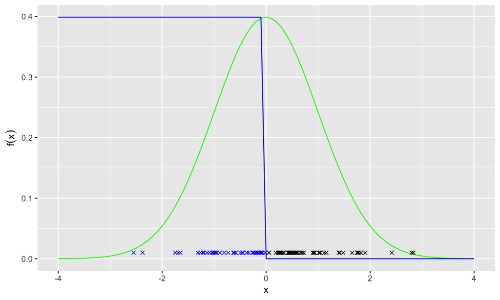

## Estimating Probabilities of Normal Distributions

```r
  set.seed(123)
  ns = c(10, 100, 1000, 10000, 100000)
  t = 0
  h <- function(x) {
    x < t
  }
  for(n in ns) {
    x_sample = rnorm(n)
    h_sample = h(x_sample)
    h_bar_n = 1/n * sum(h_sample)
    cat(sprintf("n = %d\th_bar_n = %f\n", n, h_bar_n))
  }
```

```
## n = 10   h_bar_n = 0.500000
## n = 100  h_bar_n = 0.510000
## n = 1000 h_bar_n = 0.489000
## n = 10000    h_bar_n = 0.505200
## n = 100000   h_bar_n = 0.498620
```

## Estimating Probabilities of Normal Distributions

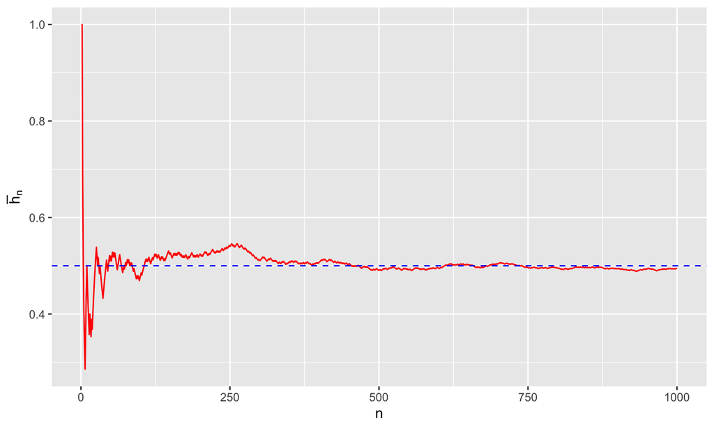

## Conclusion

## Conclusion

We’ve seen…

- What Monte-Carlo is.
- Some simple simulations.

## Independent work:

1. (Optional) Create a git repository.
2. Create an R Markdown workbook.
3. Implement Monte Carlo yourself:
   1. For \(X \sim \mathcal{N}(0,1)\), try computing \(\mathbb{P}(X < t)\) for a range of \(t\), e.g. \(t=0.5, 0.1, 0.01, 0.001\).
   2. Compare the results to the values calculated using `pnorm`, as \(n\) increases.
   3. Check convergence using similar plots to the ones presented above.
   4. (Optional) Repeat the above for: \(X \sim \textrm{Cauchy}\left(0, 1\right)\) . How do the results differ? (Hint: you may find the functions `rcauchy` and `pcauchy` helpful).
4. (Optional) Check in your code and push it to github.